# Who is considered a migrant in Post-Soviet Europe? Evidence from the Baltic States

10th Conference of the European Survey Research Association

Christian Czymara, with Anastasia Gorodzeisky, Inna Leykin

19 Jul 2023

# Introduction

## Relevance

- Immigration scholars increasingly interested in post-socialist Central and Eastern European countries
- Historically internal migration within the former socialist federations often retroactively interpreted as *international* migration
- However, it was actually movement within one sovereign state
- *How citizens in these countries imagine international migration?*

## Cases: Estonia, Latvia, Lithuania

- Geographic neighbors
- All annexed by the Soviet Union (SU) in 1940
- Little emigration from the SU; but migration within SU often promoted (e.g. central government resettlement policies)
- Independence: Estonia and Latvia in 1991, Lithuania in 1990

## Citizenship: Latvia and Estonia

- *Exclusionary citizenship laws*: Citizenship only for residents who were already citizens before 1940, and descendants
- High shares of non-citizens today (17.5% in Latvia, 15.8% in Estonia in 2010)
- Including large share of *historically internal migrants*, and descendants
- Perceived threat to the indigenous culture, language and national identity

## Citizenship: Lithuania

- *Inclusive citizenship laws*: Citizenship to all people who were legal residents in 1989
- Low share of non-citizens today (1.1% in 2010)
- Smaller and more heterogeneous minority population

## Research questions

- RQ1: How citizens in these countries imagine international migration?
- RQ2: How does historically intern immigration translate into people’s views of immigration today?
- Hypothesis 1: Historical intern migration is more relevant in Latvia and Estonia than in Lithuania
- Hypothesis 2: Racial prejudice are higher in Latvia and Estonia than in Lithuania

# Data

## Data

- National-representative online survey data collected in Fall 2022
- Open-ended question: *When you think about immigrants in [country], which group are you thinking of first of all? Please, describe the group in your own words in as many details as possible.*
- $N=$ 1233
- Mean length of answers: 10.59 (SD: 10.55)

# Results

## Topic model results

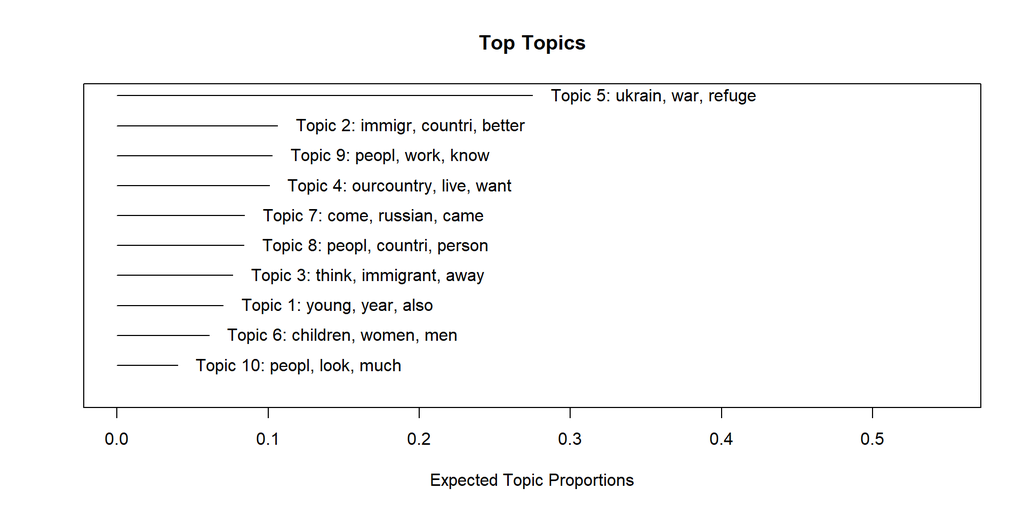

## Example answers Topic 7 (historical SU migration)

```
 Topic 7:
     Occupiers, workers who came during the soviet era, so-called builders, people with gray passports
    Russians who come from the Soviet Union
    Residents from Russian Federation, who evade sanctions, mobilization and other complications in Russia
    People who came here from other republics of the Soviet Union
    I myself am a gray passport man
    Russians who came in 70-80s
    People who came in soviet times (from other Soviet Union republics)
    I didn't come across. They don't bother anyone, I don't notice them, they don't bother anyone. I'm not interested.
```

## Example answers Topic 5 (Ukrainian refugees)

```
 Topic 5:
     Ukrainians fleeing the war. They need help.
    Ukrainians, refugees from the war are fleeing (they are usually talked about)
    Ukrainians flee from the horror of war.
    Ukrainians who are fleeing the war and who need help
    War refugees from Ukraine, Ukrainians in particular
    Refugees in connection with the war in Ukraine
    Ukrainian refugees and those from other war zones
    Ukrainians who are war refugees from Ukraine
```

## Example answers Topic 9 (Racial prejudice)

```
 Topic 9:
     would not like babai, Romanians. I don't like black people, it's different with them. I live in a village, I don't see them much. It's increasing bit by bit. There are a lot of them in Sweden, even the police are afraid of them. The same in Germany, where many of them have arrived. It will be t…
    People with Asian origin (India, Pakistan, etc.)
    People who don't go out for fun. Do not destroy people's destinies. Can't survive. Difficulties due to war
    The one who begins to slander here, a person with unpleasant behavior, does not recognize our culture and actions
    Work force, efficient doctors, smart people.
    Immigrants, who have arrived from India, Pakistan and other Asian countries. Working in catering, sale and services.
    The ones with dark skin, don't know which nation it is
```

## Cross-national differences

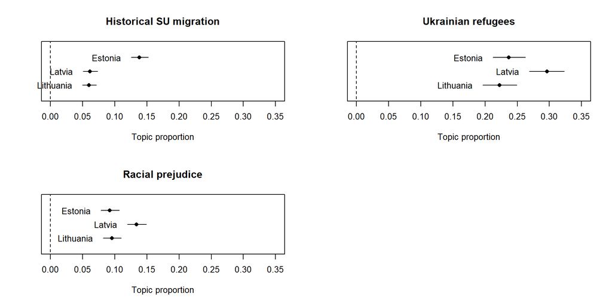

# Without answers relating to Ukraine

## Excluding Ukriane answers

- 44 percent of respondents mention Ukraine
- Dropping those answers results in a data set with 688 respondents

## Topic models without Ukraine answers

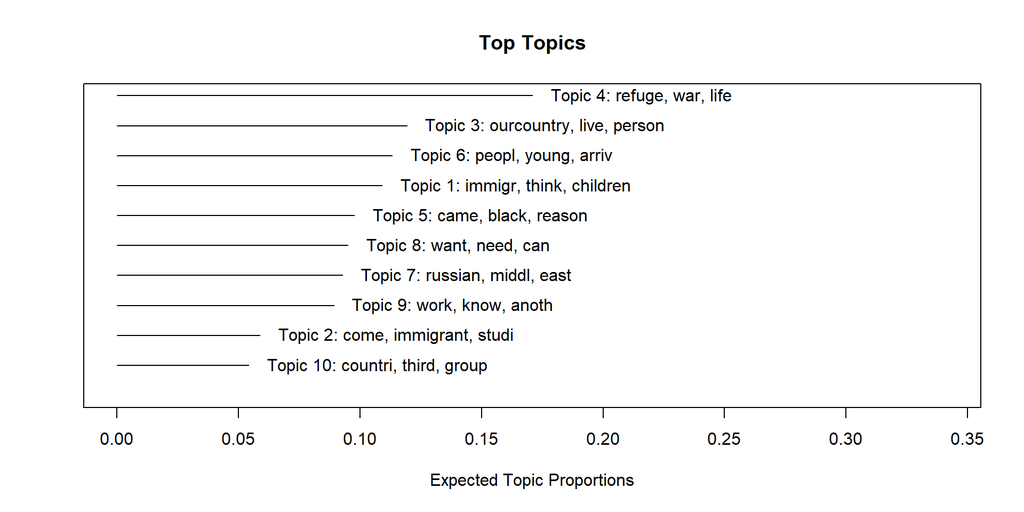

## Example answers Topic 4 (general refugees)

```
 Topic 4:
     A broad concept. A person who flees from war and situations, but more economic emigrants. More from Iraq, Afghanistan, Ivory Coast, Africa, Pakistan. More families from Iraq, but maybe more men.
    Those who are looking for an easy life, who are looking for a place for an easy life
    Seeking refuge and a better life
    Those who have ran away from their country to a place where there is a better life. Political refugees.
    Running away from trouble, from war. In search of a better life
    Economic refugees looking for a better life
    From the African country. Iraq, Iran, Afghanistan. Illegal.
```

## Example answers Topic 3 (historical SU migration)

```
 Topic 3:
     During the Soviet era, those who came from all over the USSR and still try to live according to the old laws and as in the old days, have not learned the Latvian language (in any institution they do not try to start a conversation in Latvian, they immediately speak Russian), but they enjoy all …
    Who are not locals, who have come from outside Estonia; the person was not born in Estonia or has not lived in Estonia for a long time - 20-30 years.  This is how it is considered everywhere
    Russians who have lived here for a long time but still do not speak Estonian
    Those who are not Estonians by nationality, but live in Estonia and do not have Estonian citizenship
    A person who came to Estonia from elsewhere, e.g. A Russian who came to Estonia after World War ii, has not studied Estonian but presents its demands
    A person who was not born in Estonia, but is currently living in Estonia, studying, etc.
    A person who has come to live in Estonia, without citizenship
```

## Cross-national differences without Ukraine

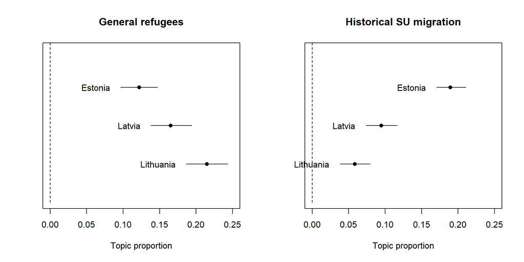

## Conclusion

- Historical differences between the Baltic state translate into different conceptions of immigration today
- Importance of external events (Russia’s war on Ukraine) can overshadow such more latent phenomena
- Examine individual-level differences (e.g. across socio-economic variables, political attitudes)

## Appendix

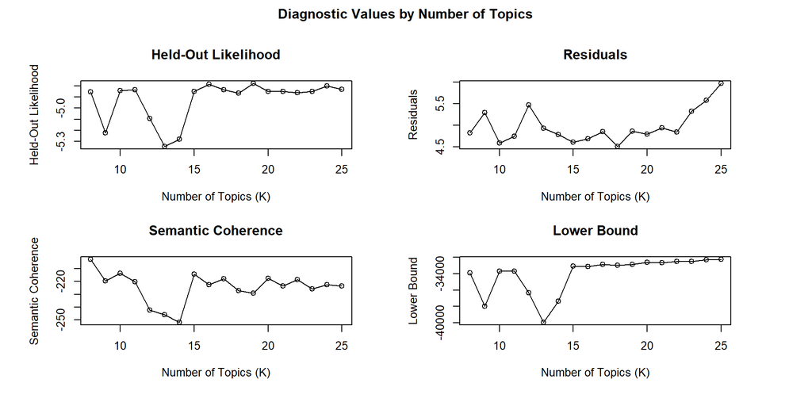